# Visualizing regression models

Last updated in March 2022

## Goals for today

- Learning how to produce point-range regression plots
- Understanding marginal effects
- Plotting marginal effects

## Point-range plots

## Point-range plots

- Straightforward visualizations of the regression coefficients tables

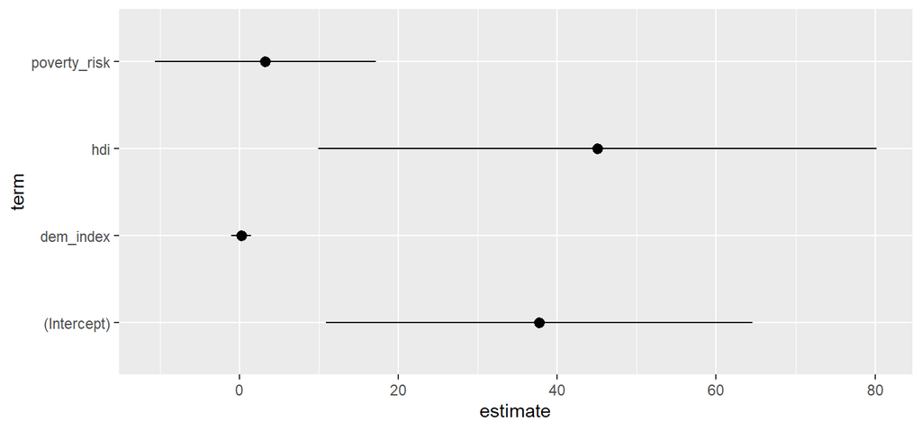

## Standardization

- Visual display invites comparison, so better standardize

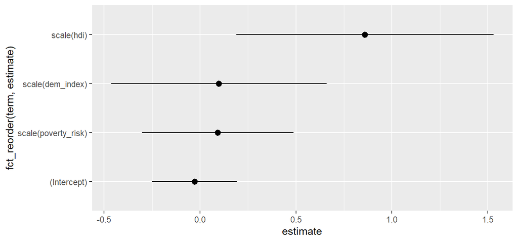

## Marginal effect plots

## Some models are easy to interpret…

- Relationship between life expectancy and democratic index, assuming linear relationship

```r
mod1 = lm(life_exp ~ dem_index, data = countries)
coef(mod1)
```

```
## (Intercept)   dem_index
##   67.191591    1.621479
```

- A country with additional point of democratic index has, on average, 1.6 years higher life expectancy

## … others not so much

- Relationship between life expectancy and democratic index, but the relationship can be parabolic and also can differ based on whether the country has a post soviet history or not.

```r
m2 = lm(life_exp ~ poly(dem_index, 2) * postsoviet,
          data = countries[!is.na(countries$dem_index),])
coef(m2)
```

```
##                       (Intercept)               poly(dem_index, 2)1
##                         80.981531                          8.327868
##               poly(dem_index, 2)2                     postsovietyes
##                         -3.296518                         -1.995878
## poly(dem_index, 2)1:postsovietyes poly(dem_index, 2)2:postsovietyes
##                          5.085355                         12.699062
```

- Help, how can I interpret this?

## Complex models are hard to interpret

- Once variables are transformed, there are interactions, quadratic terms, splines, etc., interpreting relationships between them using coefficients tables becomes difficult
- Solution: visual interpretation using marginal effects

## Marginal effects are here to save the day

- Marginal effect = expected value of the dependent variable for given values of selected independent variable while other independent variables are held constant (preferably at some reasonable value such as mean)

```r
ggpredict(m2, terms = c("dem_index [4,6,8]", "postsoviet [yes]"))
```

```
## # Predicted values of life_exp
##
## dem_index | Predicted |         95% CI
## --------------------------------------
##         4 |     79.87 | [75.00, 84.74]
##         6 |     76.25 | [75.34, 77.15]
##         8 |     78.62 | [77.55, 79.69]
```

## Marginal effects vizualized

- The plot contains the exact same information as the table of regression coefficients, but is actually interpretable

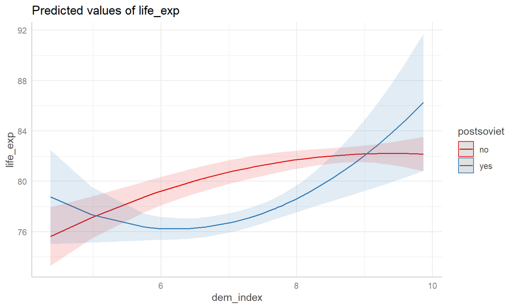

## Marginal effects

- We can also plot just one variable one, while holding the others constant
- The following plot shows the difference in expected life expectancy for countries with **average** democratic index

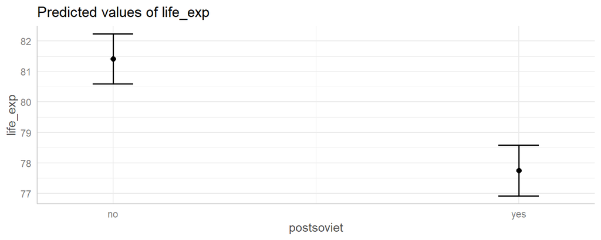

- Question: How is this plot different from displaying simply group means, i.e. mean life expectancy for the postsoviet vs. non-postsoviet?

## `ggeffects` package

- `ggeffects` package computes marginal effects and returns `ggplot2` friendly data frames
- The `ggeffects` offers three basic functions:
  - `ggpredict` - based on the base `predict()` function, works on almost any model
  - `ggeffects` - based on the `effects` package, similar to ggpredict, but handles categorical variables differently
  - `ggemeans` - based on the `emeans` package, mostly for contrasts

## `ggeffects` package is broadly applicable

- The package works for a variety of models not covered in this course
  - generalized linear models
  - (generalized) mixed models
  - bayesian models
  - survival models
  - and many more

And that is pretty cool!